# Analyzing sampling completeness

**Goals**

The next big step in this analysis is investigating how *Heliconia* removal affected interaction turnoever, i.e. network dissimilarity calculated with bipartite::betalinkr(). Before moving ahead with this analysis, however, I need to explore the extent to which networks were sampled adequately.

Specifically, if pre-to-post sampling completeness differs in treatment replicates - but not control replicates - this systematic bias in sampling might lead to a spurious treatment effect.

To explore this possibility for each sampling method, here I:

1. Summarize sampling completeness
2. Visualize how sampling completeness varies pre-to-post, control-vs-treatment
3. Statistically test whether sampling completeness varies pre-to-post, control-vs-treatment

I conclude that:

1. Sampling completeness was higher for visitation (camera) networks, which were sampled through an array of trail cameras.
2. For pollen networks, pre-to-post sampling completeness was lower in treatment replicates than in control replicates, introducing systematic sampling bias. **Therefore, for the analysis of interaction turnover, I will only analyze camera networks.**

## Step 1: Get data

Sampling completeness was calculated in script 04, where pre and post networks were created. By default, two metrics of sampling completeness were returned, ACE and Chao 1. However, calculations of sampling completeness used the raw interaction frequencies (integers) and ACE returns NA if interaction frequencies aren’t greater than 1. This led to NA for lots of pollen networks, so I will just use Chao 1.

```r
#Data
completeness <- read.csv("../data/export/for_analysis/Sampling_completeness_for_analysis.csv") %>%
  select(-X,  -contains("ACE")) %>%
  mutate(outliers = "with_outliers")

#Add a dataset without outliers
completeness_with_without_outliers <- completeness %>%
  filter(sampling_method == "visitation") %>%
  filter(year_patch != "2017_130") %>%
  filter(year_patch != "2017_24") %>%
  mutate(outliers = "without_outliers") %>%
  bind_rows(completeness)

#Functions
source("../code/helper_functions/Calculate_basic_summary_stats.R")
source("../code/helper_functions/Transform_proportion_for_betareg.R")
```

## Step 2: Summarize sampling completeness

```r
completeness_sum <- completeness_with_without_outliers %>%
  group_by(sampling_method, outliers) %>%
  calculate_basic_summary_stats(variable = completeness.chao1) %>%
  ungroup() %>%
  mutate_if(is.numeric, ~round(., digits = 2))

completeness_sum
```

```
## # A tibble: 3 × 8
##   sampling_method outliers           min   max  mean    sd median     n
##   <chr>           <chr>            <dbl> <dbl> <dbl> <dbl>  <dbl> <dbl>
## 1 pollen          with_outliers     0.17     1  0.5   0.19   0.48    49
## 2 visitation      with_outliers     0.44     1  0.91  0.11   0.93    64
## 3 visitation      without_outliers  0.7      1  0.92  0.08   0.93    60
```

## Step 3: Visualize data

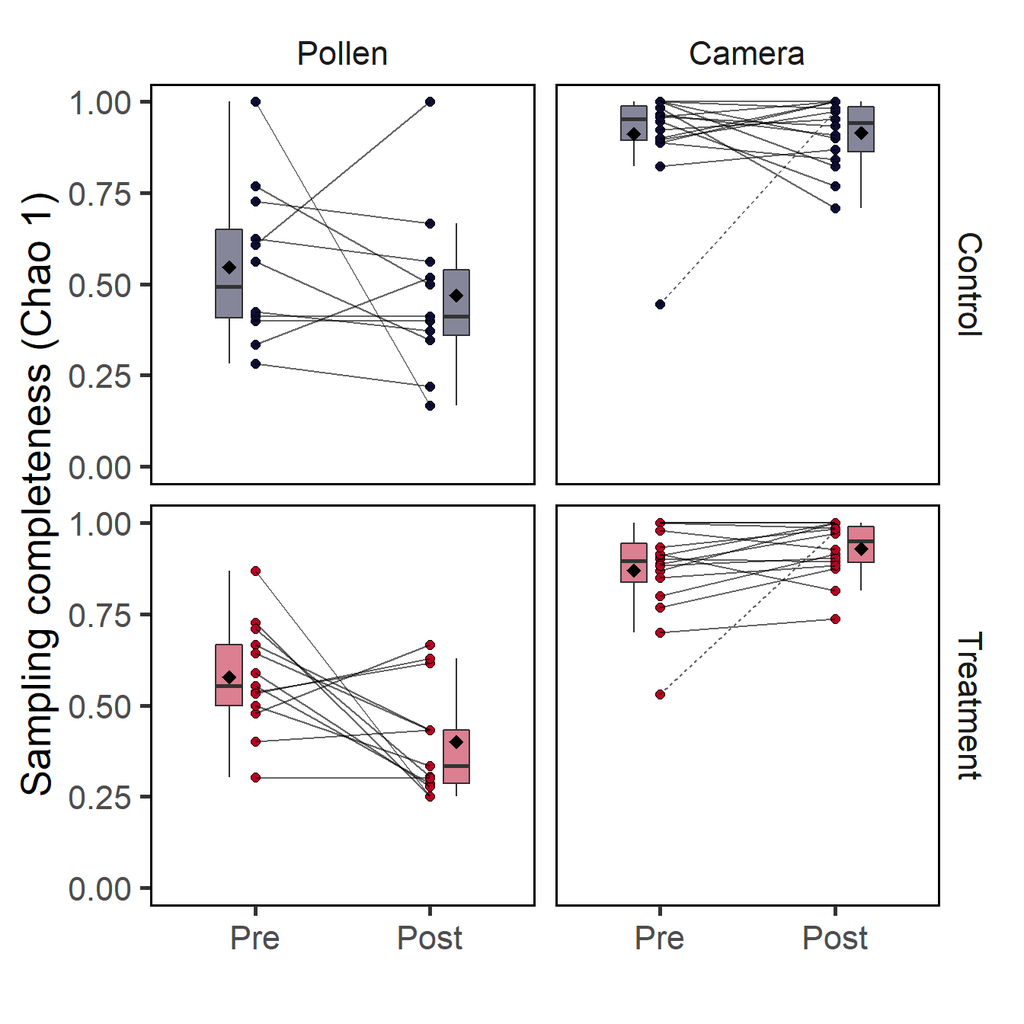

```r
#Prepare data for plotting, including adding indicator variable for outliers
data_for_plot <- completeness_with_without_outliers %>%
  filter(outliers == "with_outliers") %>%
  mutate(outlier_indicator = ifelse(sampling_method == "visitation" & (year_patch == "2017_130" | year_patch == "2017_24"), "outlier", "not_outlier")) %>%
  mutate(control_treatment = factor(control_treatment, levels = c("control", "treatment"), labels = c("Control", "Treatment"))) %>%
  mutate(exp_phase = factor(exp_phase, levels = c("pre", "post"), labels = c("Pre", "Post"))) %>%
  mutate(sampling_method = factor(sampling_method, levels = c("pollen", "visitation"), labels = c("Pollen", "Camera")))

#Make plot
colors <- c("#0E0D37", "#BA0022") #dark blue, dark red

chao1_plot <- data_for_plot %>%
  ggplot(data = ., aes(x = exp_phase, y = completeness.chao1)) +
    facet_grid(control_treatment ~ sampling_method) +
    geom_boxplot(aes(fill = control_treatment), width = 0.15, position = position_nudge(x = c(-0.15, 0.15)), alpha = 0.5, outlier.shape = NA) +
    geom_point(aes(fill = control_treatment), colour = "black", shape = 21, position = position_dodge(width = 0.45), alpha = 1, size = 2) +
    stat_summary(fun = mean, position = position_nudge(x = c(-0.15, 0.15)), geom = "point", shape = 18, size = 3) +
    geom_line(aes(group = year_patch, linetype = outlier_indicator), alpha = 0.6, size = 0.5) +
    theme_bw(base_size = 20) +
    scale_fill_manual(values = colors) +
    scale_color_manual(values = colors) +
    scale_linetype_discrete(c("solid", "dashed")) +
    theme(legend.position = "none",
          legend.direction = "horizontal",
          panel.grid.major = element_blank(),
          panel.grid.minor = element_blank(),
          strip.background = element_blank(),
          panel.border = element_rect(colour = "black", fill = NA))+
    labs(x = "", y = "Sampling completeness (Chao 1)", fill = "", colour = "") +
    scale_y_continuous(limits = c(0, 1))

chao1_plot
```

## Step 4: Statistically analyze pre-to-post changes in sampling completeness. Are there greater changes in sampling completeness depending on treatment?

Transform response variable so that it falls between 0 and 1, so I can use beta regression

```r
completeness_for_analysis <- completeness_with_without_outliers %>%
  group_by(sampling_method, outliers) %>%
  mutate(chao1_transform = transform_proportion(completeness.chao1)) %>%
  ungroup() %>%
  mutate(exp_phase = factor(exp_phase, levels = c("pre", "post")))
```

Create model for examine for each sampling method and check assumptions

```r
model_pollen <- glmmTMB::glmmTMB(chao1_transform ~ exp_phase * control_treatment + (1|patch/year_patch), data = filter(completeness_for_analysis, sampling_method == "pollen"), family = "beta_family")

model_camera <- glmmTMB::glmmTMB(chao1_transform ~ exp_phase * control_treatment + (1|patch/year_patch), data = filter(completeness_for_analysis, sampling_method == "visitation" & outliers == "with_outliers"), family = "beta_family")

model_camera_without_outliers <- glmmTMB::glmmTMB(chao1_transform ~ exp_phase * control_treatment + (1|patch/year_patch), data = filter(completeness_for_analysis, sampling_method == "visitation" & outliers == "without_outliers"), family = "beta_family")

DHARMa::simulateResiduals(model_pollen) %>% plot()
```

[output not shown]

```r
DHARMa::simulateResiduals(model_camera) %>% plot()
```

[output not shown]

```r
DHARMa::simulateResiduals(model_camera_without_outliers) %>% plot()
```

[output not shown]

Calculate relevant contrasts

```r
#Function to calculate beta regression contrasts as probability ratios, as in script 05
calculate_contrasts <- function(model){

  emm = emmeans(model, specs = ~exp_phase|control_treatment)
  emm_log = regrid(emm, transform = "log")
  #result = summary(contrast(emm_log, interaction = "revpairwise"), type = "response") #Without CI, with p-value
  result = confint(contrast(emm_log, interaction = "revpairwise"), type = "response") #With CI, without p-value

  return(result)

}

completeness_contrasts <- tibble(model_number = c(1, 2, 3),
                                 model_name = c("Pollen", "Camera", "Camera (without outliers)"),
                                 model = list(model_pollen, model_camera, model_camera_without_outliers)) %>%
  mutate(contrasts = purrr::map(model, calculate_contrasts)) %>%
  unnest(contrasts) %>%
  mutate_if(is.numeric, ~round(., digits = 2)) %>%
  select(-model)
```

## Step 5: Export results

```r
path_name <- c("../results/analyses_sampling_completeness")
write.csv(completeness_sum, file.path(path_name, "tables/Sampling_completeness_summary.csv"), row.names = FALSE)
write.csv(completeness_contrasts, file.path(path_name, "tables/Sampling_completeness_contrasts.csv"), row.names = FALSE)
ggsave(file.path(path_name, "figures/Sampling_completeness_plot.png"), plot = chao1_plot, width = 7, height = 7, units = "in", dpi = 300)
```